# Project Presentation

### Colette Yeager

## Topic

- Factors that have an influence on election results
- Determine which factors are most important in predicting future results

## Features

- Popular Vote Share vs Electoral College Share
- Voter Turnout
- Swing State Results
- Previous President's Features
- Economic Growth

## Methods

- Anticipated using both pd.read_html and Beautiful Soup
- Multiple different visualization tactics
- Would like to test mutliple different machine learning models
  - Modeling Pipeline with tuning

#### Current Tools

- So far have mostly just used read_html - data I've found has been in a table format already
- Pandas functions
- Creating functions
- Plotnine ggplot and matplotlib

## Data and Visualization

- Swing states: NM, IL, OH, CA, PA, NY, NV
  - Found by summing instances where state voted same as winning party, kept states above 0.8 accuracy
- Compiled all of the data into one larger dataframe for reference

```
[[0.8928571428571429, 'New Mexico'],
 [0.8235294117647058, 'Illinois'],
 [0.8181818181818182, 'Ohio'],
 [0.813953488372093, 'California'],
 [0.8135593220338984, 'Pennsylvania'],
 [0.8103448275862069, 'New York'],
 [0.8, 'Nevada']]
```

|  | Year | President | Electoral College | Popular Vote | Change in GDP in % | Turnout Rate | Party | New Mexico | Illinois | Ohio | California | Pennsylvania | New York | Nevada |
| --- | --- | --- | --- | --- | --- | --- | --- | --- | --- | --- | --- | --- | --- | --- |
| 0 | 1789 | George Washington | 100.00 | NaN | NaN | 11.6 | GW | 0 | 0 | 0 | 0 | 1 | 0 | 0 |
| 1 | 1792 | George Washington | 100.00 | NaN | NaN | 6.3 | GW | 0 | 0 | 0 | 0 | 1 | 1 | 0 |
| 2 | 1796 | John Adams | 51.45 | NaN | NaN | 20.1 | F | 0 | 0 | 0 | 0 | 0 | 1 | 0 |
| 3 | 1800 | Thomas Jefferson | 52.90 | NaN | NaN | 32.3 | DR | 0 | 0 | 0 | 0 | 1 | 1 | 0 |
| 4 | 1804 | Thomas Jefferson | 92.05 | NaN | NaN | 23.8 | DR | 0 | 0 | 1 | 0 | 1 | 1 | 0 |

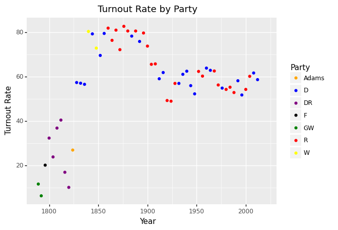

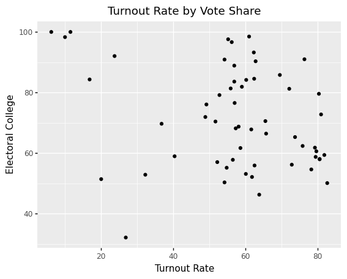

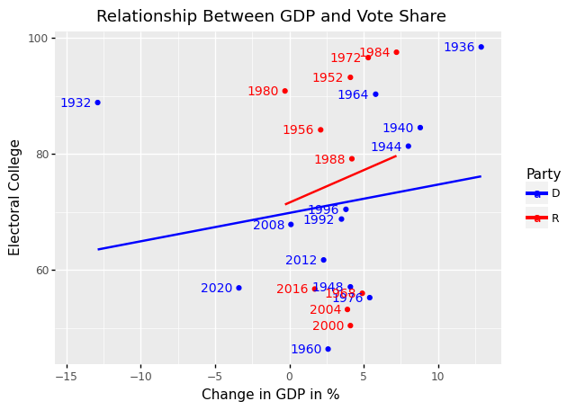

## Challenges

- Have had to define some assumptions to make data simpler
- Difficult to access some data - turnout by party
- Often necessary to change plans depending on available data

## Next Steps

- Will need to add previous president info
- Add modeling steps
- Compare relevance of features
  - Would expect the most accurate swing states significantly impact percentage of vote
- Can also do some analysis on how the other features interact